# Summaries

Kaisa Roots

2019-03-28

```r
library(tidyverse)
library(nycflights13)
```

dplyr summarise() function can be used to calculate counts and proportions of logical values: sum(x > 10), mean(y == 0).

When used with numeric functions, TRUE is converted to 1 and FALSE to 0.

> This makes sum() and mean() very useful: sum(x) gives the number of TRUEs in x, and mean(x) gives the proportion.

### Exercises

1. Using nycflights13 “flights” dataset, brainstorm at least 5 different ways to assess the typical delay characteristics of a group of flights.

```r
flights
```

```
## # A tibble: 336,776 x 19
##     year month   day dep_time sched_dep_time dep_delay arr_time
##    <int> <int> <int>    <int>          <int>     <dbl>    <int>
##  1  2013     1     1      517            515         2      830
##  2  2013     1     1      533            529         4      850
##  3  2013     1     1      542            540         2      923
##  4  2013     1     1      544            545        -1     1004
##  5  2013     1     1      554            600        -6      812
##  6  2013     1     1      554            558        -4      740
##  7  2013     1     1      555            600        -5      913
##  8  2013     1     1      557            600        -3      709
##  9  2013     1     1      557            600        -3      838
## 10  2013     1     1      558            600        -2      753
## # … with 336,766 more rows, and 12 more variables: sched_arr_time <int>,
## #   arr_delay <dbl>, carrier <chr>, flight <int>, tailnum <chr>,
## #   origin <chr>, dest <chr>, air_time <dbl>, distance <dbl>, hour <dbl>,
## #   minute <dbl>, time_hour <dttm>
```

Consider the following scenarios:

- A flight is 15 minutes early 50% of the time, and 15 minutes late 50% of the time.

```r
flights %>%
  group_by(flight) %>%
  summarize(n = n(),
            fifteen_early = mean(arr_delay == -15, na.rm = TRUE),
            fifteen_late = mean(arr_delay == 15, na.rm =TRUE)) %>%
  filter(fifteen_early == 0.5 | fifteen_late == 0.5)
```

```
## # A tibble: 7 x 4
##   flight     n fifteen_early fifteen_late
##    <int> <int>         <dbl>        <dbl>
## 1    730     2           0            0.5
## 2   1780     2           0.5          0
## 3   2072     2           0.5          0
## 4   3409     2           0            0.5
## 5   4081     2           0.5          0
## 6   4313     2           0            0.5
## 7   5710     2           0.5          0
```

- A flight is always 10 minutes late.

```r
flights %>%
  group_by(flight) %>%
  summarize(n = n(),
            ten_late = mean(arr_delay == 10, na.rm = TRUE)) %>%
  filter(ten_late == 1)
```

```
## # A tibble: 5 x 3
##   flight     n ten_late
##    <int> <int>    <dbl>
## 1   2254     1        1
## 2   3656     1        1
## 3   3785     2        1
## 4   3880     1        1
## 5   5854     1        1
```

- A flight is 30 minutes early 50% of the time, and 30 minutes late 50% of the time.

```r
flights %>%
  group_by(flight) %>%
  summarize(n = n(),
            thirty_early = mean(arr_delay == -30, na.rm = TRUE),
            thirty_late = mean(arr_delay == 30, na.rm =TRUE)) %>%
  filter(thirty_early == 0.5 & thirty_late == 0.5)
```

```
## # A tibble: 0 x 4
## # … with 4 variables: flight <int>, n <int>, thirty_early <dbl>,
## #   thirty_late <dbl>
```

- 99% of the time a flight is on time. 1% of the time it’s 2 hours late.

```r
flights %>%
  group_by(flight) %>%
  summarize(n = n(),
            percentage_on_time = mean(arr_delay == 0, na.rm = TRUE),
            two_hours = mean(arr_delay > 120, na.rm = TRUE)) %>%
  filter(percentage_on_time == 0.99 & two_hours == 0.01)
```

```
## # A tibble: 0 x 4
## # … with 4 variables: flight <int>, n <int>, percentage_on_time <dbl>,
## #   two_hours <dbl>
```

- Which is more important: arrival delay or departure delay?

Both arrival delay and departure delay are unwanted. With arrival delay, many other flights are affected and connected flights might be missed. However, departure delay directly contibutes to arrival delay. Additionally, the difference between arrival delay and departure delay are used to define air time, hence real arrival time can show whether any problems during the flight have occured.

2. Come up with another approach that will give you the same output as not_cancelled %>% count(dest) and not_cancelled %>% count(tailnum, wt = distance) (without using count()).

```r
not_cancelled <- flights %>%
  filter(!is.na(dep_delay), !is.na(arr_delay))
not_cancelled
```

```
## # A tibble: 327,346 x 19
##     year month   day dep_time sched_dep_time dep_delay arr_time
##    <int> <int> <int>    <int>          <int>     <dbl>    <int>
##  1  2013     1     1      517            515         2      830
##  2  2013     1     1      533            529         4      850
##  3  2013     1     1      542            540         2      923
##  4  2013     1     1      544            545        -1     1004
##  5  2013     1     1      554            600        -6      812
##  6  2013     1     1      554            558        -4      740
##  7  2013     1     1      555            600        -5      913
##  8  2013     1     1      557            600        -3      709
##  9  2013     1     1      557            600        -3      838
## 10  2013     1     1      558            600        -2      753
## # … with 327,336 more rows, and 12 more variables: sched_arr_time <int>,
## #   arr_delay <dbl>, carrier <chr>, flight <int>, tailnum <chr>,
## #   origin <chr>, dest <chr>, air_time <dbl>, distance <dbl>, hour <dbl>,
## #   minute <dbl>, time_hour <dttm>
```

##### 1

```r
not_cancelled %>%
  count(dest)
```

```
## # A tibble: 104 x 2
##    dest      n
##    <chr> <int>
##  1 ABQ     254
##  2 ACK     264
##  3 ALB     418
##  4 ANC       8
##  5 ATL   16837
##  6 AUS    2411
##  7 AVL     261
##  8 BDL     412
##  9 BGR     358
## 10 BHM     269
## # … with 94 more rows
```

```r
not_cancelled %>%
  group_by(dest) %>%
  summarize(n = n())
```

```
## # A tibble: 104 x 2
##    dest      n
##    <chr> <int>
##  1 ABQ     254
##  2 ACK     264
##  3 ALB     418
##  4 ANC       8
##  5 ATL   16837
##  6 AUS    2411
##  7 AVL     261
##  8 BDL     412
##  9 BGR     358
## 10 BHM     269
## # … with 94 more rows
```

##### 2

```r
not_cancelled %>%
  count(tailnum, wt = distance)
```

```
## # A tibble: 4,037 x 2
##    tailnum      n
##    <chr>    <dbl>
##  1 D942DN    3418
##  2 N0EGMQ  239143
##  3 N10156  109664
##  4 N102UW   25722
##  5 N103US   24619
##  6 N104UW   24616
##  7 N10575  139903
##  8 N105UW   23618
##  9 N107US   21677
## 10 N108UW   32070
## # … with 4,027 more rows
```

```r
not_cancelled %>%
  group_by(tailnum) %>%
  summarize(n = sum(distance))
```

```
## # A tibble: 4,037 x 2
##    tailnum      n
##    <chr>    <dbl>
##  1 D942DN    3418
##  2 N0EGMQ  239143
##  3 N10156  109664
##  4 N102UW   25722
##  5 N103US   24619
##  6 N104UW   24616
##  7 N10575  139903
##  8 N105UW   23618
##  9 N107US   21677
## 10 N108UW   32070
## # … with 4,027 more rows
```

3. Our definition of cancelled flights (is.na(dep_delay) | is.na(arr_delay) ) is slightly suboptimal. Why? Which is the most important column?

We assume that if a flight did not leave it was cancelled. Therefore, when the condition is.na(dep_delay) is met, the flight was cancelled.

4. Look at the number of cancelled flights per day. Is there a pattern? Is the proportion of cancelled flights related to the average delay?

```r
flights %>%
  group_by(day) %>%
  summarize(cancelled = mean(is.na(dep_delay)))
```

```
## # A tibble: 31 x 2
##      day cancelled
##    <int>     <dbl>
##  1     1   0.0223
##  2     2   0.0231
##  3     3   0.00972
##  4     4   0.00741
##  5     5   0.0208
##  6     6   0.0268
##  7     7   0.0289
##  8     8   0.0817
##  9     9   0.0546
## 10    10   0.0477
## # … with 21 more rows
```

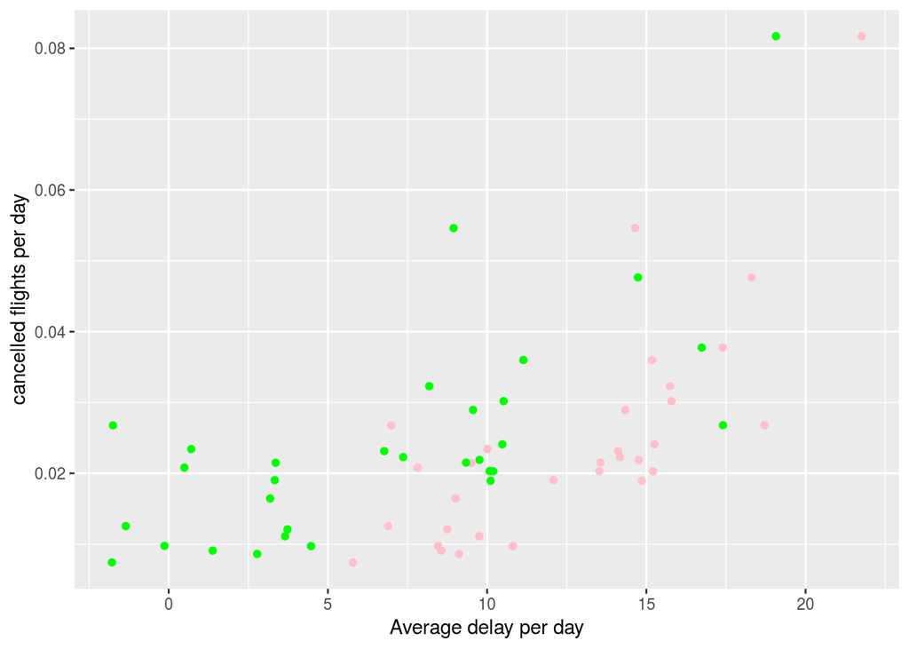

```r
flights %>%
  group_by(day) %>%
  summarize(cancelled = mean(is.na(dep_delay)),
            dep_del = mean(dep_delay, na.rm = TRUE),
            arr_del = mean(arr_delay, na.rm = TRUE)) %>%
  ggplot(aes(y = cancelled)) +
  geom_point(aes(x = dep_del), colour = "pink") +
  geom_point(aes(x = arr_del), colour = "green") +
  labs(x = "Average delay per day", y = "cancelled flights per day")
```

This plot shows us that there are more cancelled flights on days with more departure and arrival delays, which is logical, because a delay of a flight affects other flights as well. We also see that there are more departure delays (pink) on an average day.

5. Which carrier has the worst delays? Challenge: can you disentangle the effects of bad airports vs. bad carriers? Why/why not? (Hint: think about flights %>% group_by(carrier, dest) %>% summarise(n()))

```r
flights %>%
  group_by(carrier) %>%
  summarize(n = n(),
            dep_max = max(dep_delay, na.rm=TRUE),
            arr_max = max(arr_delay, na.rm=TRUE)) %>%
  arrange(desc(dep_max, arr_max)) %>%
  filter(1 : n() == 1)
```

```
## # A tibble: 1 x 4
##   carrier     n dep_max arr_max
##   <chr>   <int>   <dbl>   <dbl>
## 1 HA        342    1301    1272
```

```r
flights %>%
  group_by(carrier, dest) %>%
  summarize(n = n(),
            dep_max = max(dep_delay, na.rm=TRUE),
            arr_max = max(arr_delay, na.rm=TRUE)) %>%
  arrange(desc(dep_max, arr_max)) %>%
  filter(1 : n() == 1)
```

```
## # A tibble: 16 x 5
## # Groups:   carrier [16]
##    carrier dest      n dep_max arr_max
##    <chr>   <chr> <int>   <dbl>   <dbl>
##  1 HA      HNL     342    1301    1272
##  2 MQ      CMH    2691    1137    1127
##  3 AA      SFO    1422    1014    1007
##  4 DL      TPA    2129     960     931
##  5 F9      DEN     685     853     834
##  6 9E      CLT     291     747     744
##  7 VX      SFO    2197     653     676
##  8 FL      ATL    2337     602     572
##  9 EV      STL    1826     548     538
## 10 B6      MCO    6472     502     497
## 11 US      CLT    8632     500     492
## 12 UA      CLE    1890     483     455
## 13 WN      STL    1469     471     453
## 14 YV      CLT     282     387     381
## 15 AS      SEA     714     225     198
## 16 OO      CLE      24     154     140
```

6. What does the sort argument to count() do. When might you use it?

If TRUE, ‘sort’ will sort count() output in descending order of n.

```r
flights %>%
  count(carrier, sort = TRUE)
```

```
## # A tibble: 16 x 2
##    carrier     n
##    <chr>   <int>
##  1 UA      58665
##  2 B6      54635
##  3 EV      54173
##  4 DL      48110
##  5 AA      32729
##  6 MQ      26397
##  7 US      20536
##  8 9E      18460
##  9 WN      12275
## 10 VX       5162
## 11 FL       3260
## 12 AS        714
## 13 F9        685
## 14 YV        601
## 15 HA        342
## 16 OO         32
```

```r
flights %>%
  count(flight, sort = TRUE)
```

```
## # A tibble: 3,844 x 2
##    flight     n
##     <int> <int>
##  1     15   968
##  2     27   898
##  3    181   882
##  4    301   871
##  5    161   786
##  6    695   782
##  7   1109   716
##  8    745   711
##  9    359   709
## 10      1   701
## # … with 3,834 more rows
```